# Modeling Longitudinal Data Using Robust Mixed Models

2025-03-17

[figure not shown]

## Overview

- Introduction to linear mixed models
- The R package **skewlmm**
- Challenge 1: within subject serial correlation
- Challenge 2: outliers
- Challenge 3: skewness
- Challenge 4: censored/missing data

## Introduction to linear mixed models

## Motivation

**Goal**: Evaluate the impact of different high-fat diets on mice, two kinds of supplementation were considered, in addition to a standard high-fat diet (control).

Available in the R package **skewlmm**.

The weight of 52 mice was evaluated at baseline (week 0), and at weeks 1,2,…,10 of treatment.

```r
data(miceweight)
head(miceweight, 4)
```

```
##   treat mouseID week weight
## 1     C     101    0   33.8
## 2     C     101    1   37.2
## 3     C     101    2   34.8
## 4     C     101    3   38.3
```

## `help(miceweight)`

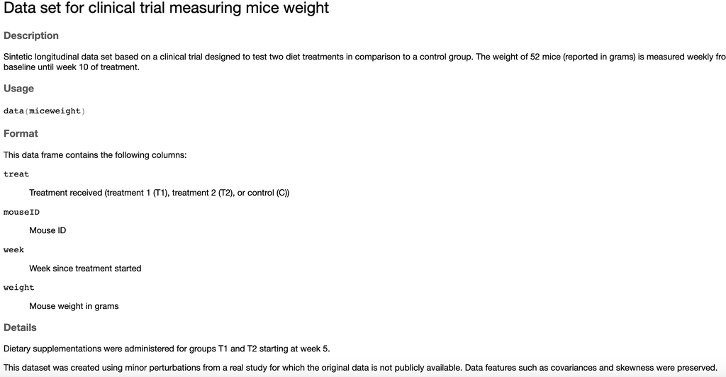

## Motivation

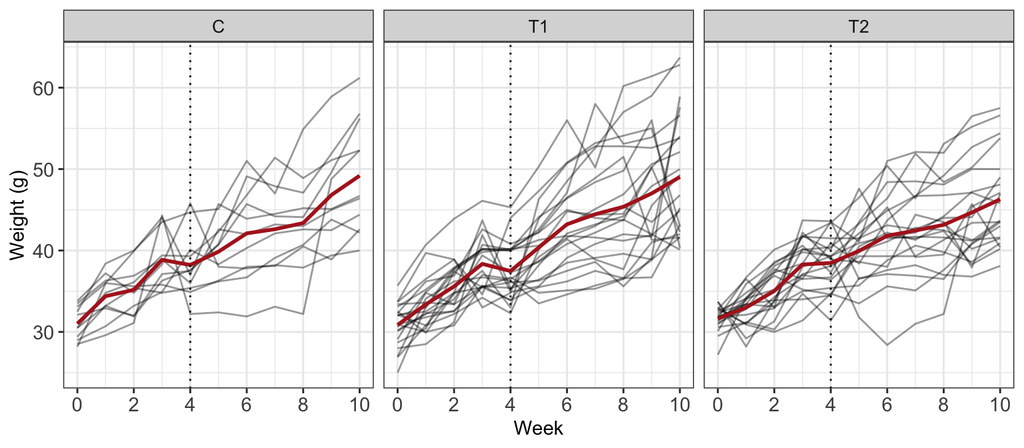

## Linear mixed models

Linear mixed-effects models (LMMs) are an important class of statistical models that can be used to analyze correlated data. They are particularly useful for handling:

- repeated measures data;
- clustered data;
- **longitudinal studies**.

Such data are encountered in a variety of fields including biostatistics, public health, psychometrics, educational measurement, sociology and geophysics.

LMMs were introduced by Laird & Ware (1982)Laird, N. M., & Ware, J. H. (1982). Random-effects models for longitudinal data. *Biometrics*, 963-974. and allow to incorporate both “**fixed**” effects and “**random**” effects, as well as (possibly correlated) errors.

## LMMs

The linear mixed-effects model is defined as

\[ \mathbf{Y}_{i}= \mathbf{X}_i \boldsymbol{\beta} + \mathbf{Z}_i\mathbf{b}_i + \boldsymbol{\epsilon}_{i}, \quad i = 1, \ldots, n, \]

where

- \(\mathbf{Y}_i\) : (\(n_i\times 1\)) vector of observations for subject \(i\),
- \(\boldsymbol\beta\) : (\(p \times 1\)) vector of fixed effects regression coefficients,
- \(\mathbf{X}_i\) : (\(n_i\times p\)) covariate (design) matrix for fixed effects,
- \(\mathbf{b}_i\) : (\(q \times 1\)) vector of random effects for subject \(i\),
- \(\mathbf{Z}_i\) : (\(n_i\times q\)) covariate (design) matrix for random effects,
- \(\boldsymbol{\epsilon}_i\) : (\(n_i\times 1\)) vector of (possibly correlated) error terms for subject \(i\).

**Remark:**  
**Fixed effects** refer to average effect in population;  
**Random effects** are specific to each subject.

## Random effects

Most commonly, in longitudinal studies we consider random intercepts (\(b_{0i}\)) and random slopes on time (\(b_{1i}\)):

- Random intercepts → individuals randomly distributed about population mean intercept,
- Random slope → individuals have rates of change randomly distributed about population mean.

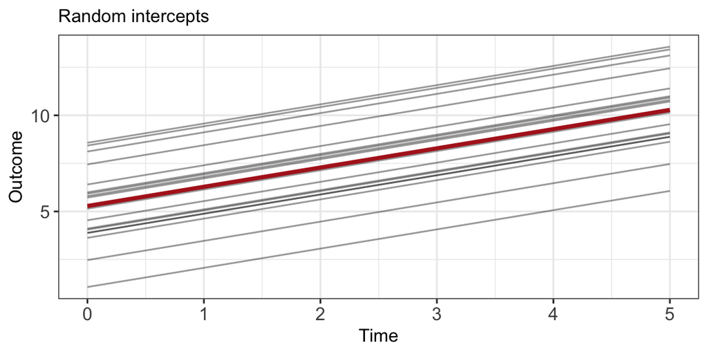

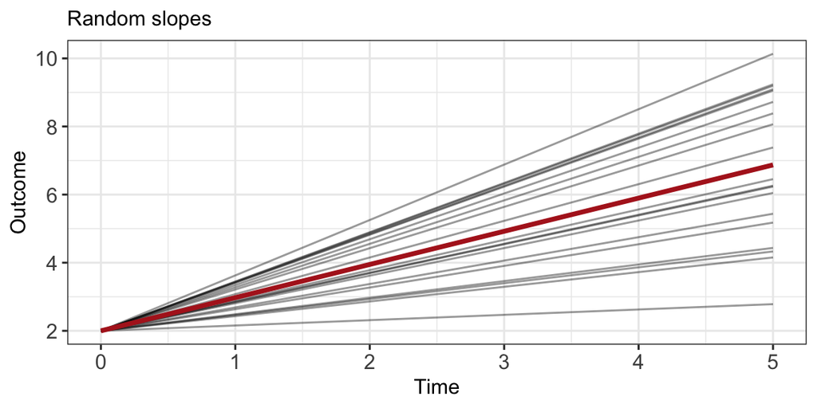

## LMMs

In the model, \[ \mathbf{Y}_{i}= \mathbf{X}_i\boldsymbol{\beta} + \mathbf{Z}_i \mathbf{b}_i + \boldsymbol{\epsilon}_{i}, \]

we typically assume that the random effects are independent of the error terms and that

\[ \mathbf{b}_i \sim N(\mathbf{0}, \mathbf{D}), \] \[ \boldsymbol\epsilon_i \sim N(\mathbf{0}, \boldsymbol{\Omega}_i). \]

This assumption yields a covariance structure for the outcomes

\[ \text{Var}(\mathbf{Y}_i) = \boldsymbol{\Sigma}_i= \mathbf{Z}_i \mathbf{DZ}_i^\top + \boldsymbol{\Omega}_i. \]

**Remark:**  
The random effect structure implies correlation between the outcomes!

## LMM - Interpretation

The expected model for subject \(i\) is

\[ E(\mathbf{Y}_i|\mathbf{X}_i, \mathbf{b}_i) = \mathbf{X}_i\boldsymbol\beta + \mathbf{Z}_i\mathbf{b}_i. \]

This interpretation of the mean given the subject-specific effect is called “conditional” interpretation.

- If the random effects \(\mathbf{b}_i\) are \(\mathbf{0}\) (i.e., a “typical” individual), the model simplifies, and the fixed effects \(\boldsymbol{\beta}\) are interpreted as the expected values for this typical individual.

The average over the random effects leads to a population-averaged “marginal” interpretation:

\[ E(E(\mathbf{Y}_i|\mathbf{X}_i,\mathbf{b}_i)) = \mathbf{X}_i\boldsymbol\beta. \]

So the fixed effects (\(\boldsymbol\beta\) coefficients) are also the estimated values in the population.

## Mixed Models - Interpretation

Our model is

\[ \mathbf{Y}_{i}= \mathbf{X}_i\boldsymbol{\beta} + \mathbf{Z}_i \mathbf{b}_i + \boldsymbol{\epsilon}_{i}. \]

If we fit a model with only random intercepts, we have

\[ \mathbf{Y}_{i}= \mathbf{X}_i\boldsymbol\beta + b_{0i} + \boldsymbol\epsilon_{i}. \]

We assume that \(b_{0i} \sim N(0, \sigma^2_b)\) and \(\boldsymbol\epsilon_i \sim N(\mathbf{0}, \sigma^2_e\mathbf{I})\), where

- \(\sigma^2_e\) is the amount of random variability (of the residuals),
- \(\sigma^2_b\) is the amount of variability in the population around the population average line.

## LMMs in R

Two main popular functions to fit LMMs in R are:

- `lme()` in the **nlme** package: supports several random effects and error level dependence structures;
- `lmer()` in the **lme4** package: has more efficient linear algebra tools and is more efficient for fitting models with crossed random effects, but does not support special dependence structures.

**Remark:**  
Both these functions assume normal distributions for the random terms  
(although the function `glmer()` in the **lme4** package fits generalized linear mixed effect models).

## Fitting a LMM for miceweight data

Fitting the model \[ \begin{aligned} \mathbf{y}_{i} = & (b_{0i} +\beta_0+ \beta_1\,\text{treat}_{1i}+ \beta_2\,\text{treat}_{2i})\mathbf{1}_{n_i} \\ & + (b_{1i}+\beta_3+\beta_4\,\text{treat}_{1i}+\beta_5\,\text{treat}_{2i}) {\bf t}_i +\mathbb{\epsilon}_{i} \end{aligned} \] where \(y_{i}\) denotes the weight in grams (g) and \(t_{ij}\) denotes the numbers of weeks of diet, for \(t_{i1}=5, t_{i2}=6, \ldots, t_{i6}=10\), \(i = 1, \ldots, 52\). Also, \(t_{ij}\) is (week - 7.5).

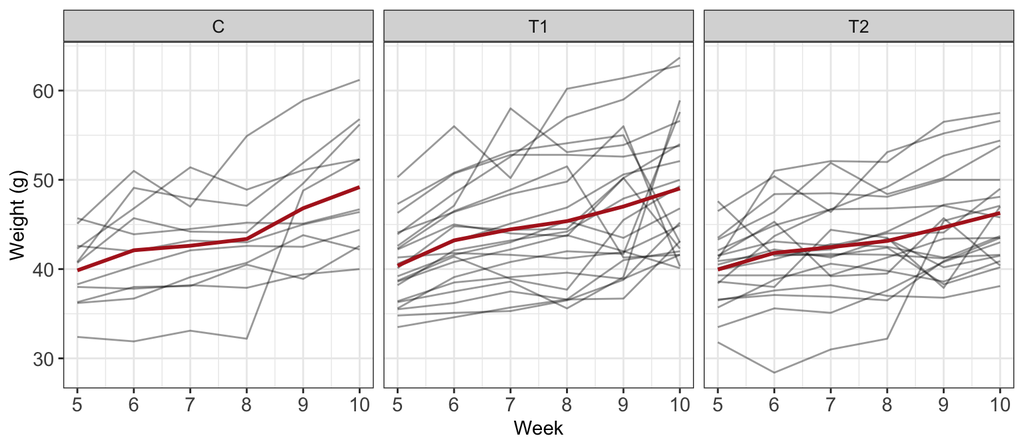

## Fitting a LMM for miceweight data

```r
# Using lme4
flme4 <- lmer(formula = weight ~ treat*weekt +
               (weekt|mouseID), data = miceweight)
summary(flme4)
```

```
## Linear mixed model fit by REML ['lmerMod']
## Formula: weight ~ treat * weekt + (weekt | mouseID)
##    Data: miceweight
##
## REML criterion at convergence: 1721.4
##
## Scaled residuals:
##     Min      1Q  Median      3Q     Max
## -3.2513 -0.4116  0.0017  0.3597  3.9826
##
## Random effects:
##  Groups   Name        Variance Std.Dev. Corr
##  mouseID  (Intercept) 24.4380  4.9435
##           weekt        0.9716  0.9857   0.29
##  Residual              7.5729  2.7519
## Number of obs: 312, groups:  mouseID, 52
##
## Fixed effects:
##               Estimate Std. Error t value
## (Intercept)    43.9939     1.5285  28.782
## treatT1         0.9156     1.8868   0.485
## treatT2        -0.9389     1.9030  -0.493
## weekt           1.7590     0.3573   4.923
## treatT1:weekt  -0.1704     0.4411  -0.386
## treatT2:weekt  -0.5881     0.4448  -1.322
##
## Correlation of Fixed Effects:
##             (Intr) tretT1 tretT2 weekt  trtT1:
## treatT1     -0.810
## treatT2     -0.803  0.651
## weekt        0.232 -0.188 -0.186
## treatT1:wkt -0.188  0.232  0.151 -0.810
## treatT2:wkt -0.186  0.151  0.232 -0.803  0.651
```

```r
# Using nlme
fnlme <- lme(weight ~ treat*weekt, data = miceweight,
             random = ~ weekt|mouseID)
summary(fnlme)
```

```
## Linear mixed-effects model fit by REML
##   Data: miceweight
##        AIC      BIC    logLik
##   1741.393 1778.629 -860.6965
##
## Random effects:
##  Formula: ~weekt | mouseID
##  Structure: General positive-definite, Log-Cholesky parametrization
##             StdDev    Corr
## (Intercept) 4.9434538 (Intr)
## weekt       0.9857314 0.286
## Residual    2.7518810
##
## Fixed effects:  weight ~ treat * weekt
##                  Value Std.Error  DF   t-value p-value
## (Intercept)   43.99394 1.5285131 257 28.782179  0.0000
## treatT1        0.91558 1.8868376  49  0.485248  0.6297
## treatT2       -0.93894 1.9029835  49 -0.493404  0.6239
## weekt          1.75896 0.3573133 257  4.922742  0.0000
## treatT1:weekt -0.17039 0.4410771 257 -0.386303  0.6996
## treatT2:weekt -0.58810 0.4448514 257 -1.322023  0.1873
##  Correlation:
##               (Intr) tretT1 tretT2 weekt  trtT1:
## treatT1       -0.810
## treatT2       -0.803  0.651
## weekt          0.232 -0.188 -0.186
## treatT1:weekt -0.188  0.232  0.151 -0.810
## treatT2:weekt -0.186  0.151  0.232 -0.803  0.651
##
## Standardized Within-Group Residuals:
##          Min           Q1          Med           Q3          Max
## -3.251342407 -0.411642381  0.001663696  0.359700449  3.982562482
##
## Number of Observations: 312
## Number of Groups: 52
```

## Plotting the random effects

```r
randomEffects = ranef(fnlme)
```

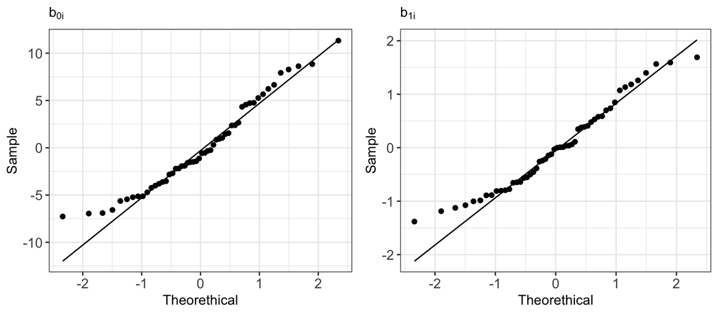

**Remark:**  
It is assumed \(\mathbf{b}_i \sim N_2(\mathbf{0}, \mathbf{D})\).

## The R package **skewlmm**

## The R package **skewlmm**

The **skewlmm** packageSchumacher, F. L., Matos, L. A., Valeriano, K. A. L., & Lachos, V. H. (2023). skewlmm: Scale Mixture of Skew-Normal Linear Mixed Models. R package version 1.1.0. contains flexible and robust models for longitudinal data. It can be installed from GitHub or its released version from CRAN as follows:

```r
remotes::install_github("fernandalschumacher/skewlmm")
#or
install.packages("skewlmm")
```

Its three main functions are *smn.lmm*, *smsn.lmm*, and *smn.clmm*:

```r
library(skewlmm)
smn.lmm(data, formFixed, groupVar, ...)
smsn.lmm(data, formFixed, groupVar, ...)
smn.clmm(data, formFixed, groupVar, ci, lcl, ucl, ...)
```

## Fitting a LMM for miceweight data

```r
fskewlmm <- smn.lmm(formFixed = weight ~ treat*weekt, formRandom = ~ weekt,
                   groupVar = "mouseID", data = miceweight)
summary(fskewlmm)
```

```
## Linear mixed models with distribution norm and dependency structure UNC
## Call:
## smn.lmm(data = miceweight, formFixed = weight ~ treat * weekt,
##     groupVar = "mouseID", formRandom = ~weekt)
##
## Distribution norm
## Random effects:
##   Formula: ~weekt
##   Structure:
##   Estimated variance (D):
##             (Intercept)     weekt
## (Intercept)   22.952931 1.3137366
## weekt          1.313737 0.8853784
##
## Fixed effects: weight ~ treat * weekt
## with approximate confidence intervals
##                    Value Std.error CI 95% lower CI 95% upper
## (Intercept)   43.9939394 1.6480925    40.763737   47.2241414
## treatT1        0.9155844 1.9111436    -2.830188    4.6613571
## treatT2       -0.9389394 1.9806544    -4.820951    2.9430719
## weekt          1.7589610 0.3746267     1.024706    2.4932159
## treatT1:weekt -0.1703896 0.4492493    -1.050902    0.7101229
## treatT2:weekt -0.5881039 0.4344989    -1.439706    0.2634984
##
## Dependency structure: UNC
##   Estimate(s):
##   sigma2
## 7.579361
##
## Model selection criteria:
##    logLik      AIC      BIC
##  -862.978 1745.957 1783.387
##
## Number of observations: 312
## Number of groups: 52
```

## Fitting a LMM for miceweight data

```r
fskewlmm
```

```
## Linear mixed models with distribution norm and dependency structure UNC
## Call:
## smn.lmm(data = miceweight, formFixed = weight ~ treat * weekt,
##     groupVar = "mouseID", formRandom = ~weekt)
##
## Fixed: weight ~ treat * weekt
## Random:
##   Formula: ~weekt
##   Structure: General positive-definite
##   Estimated variance (D):
##             (Intercept)     weekt
## (Intercept)   22.952931 1.3137366
## weekt          1.313737 0.8853784
##
## Estimated parameters:
##      (Intercept) treatT1 treatT2  weekt treatT1:weekt treatT2:weekt sigma2
##          43.9939  0.9156 -0.9389 1.7590       -0.1704       -0.5881 7.5794
## s.e.      1.6481  1.9111  1.9807 0.3746        0.4492        0.4345 0.5441
##      Dsqrt11 Dsqrt12 Dsqrt22
##       4.7854  0.2306  0.9123
## s.e.  0.7351  0.1937  0.2028
##
## Model selection criteria:
##    logLik      AIC      BIC
##  -862.978 1745.957 1783.387
##
## Number of observations: 312
## Number of groups: 52
```

## `smn.lmm` vs `lmer`

```r
# Using smn.lmm
summary(fskewlmm)
```

```
## Linear mixed models with distribution norm and dependency structure UNC
## Call:
## smn.lmm(data = miceweight, formFixed = weight ~ treat * weekt,
##     groupVar = "mouseID", formRandom = ~weekt)
##
## Distribution norm
## Random effects:
##   Formula: ~weekt
##   Structure:
##   Estimated variance (D):
##             (Intercept)     weekt
## (Intercept)   22.952931 1.3137366
## weekt          1.313737 0.8853784
##
## Fixed effects: weight ~ treat * weekt
## with approximate confidence intervals
##                    Value Std.error CI 95% lower CI 95% upper
## (Intercept)   43.9939394 1.6480925    40.763737   47.2241414
## treatT1        0.9155844 1.9111436    -2.830188    4.6613571
## treatT2       -0.9389394 1.9806544    -4.820951    2.9430719
## weekt          1.7589610 0.3746267     1.024706    2.4932159
## treatT1:weekt -0.1703896 0.4492493    -1.050902    0.7101229
## treatT2:weekt -0.5881039 0.4344989    -1.439706    0.2634984
##
## Dependency structure: UNC
##   Estimate(s):
##   sigma2
## 7.579361
##
## Model selection criteria:
##    logLik      AIC      BIC
##  -862.978 1745.957 1783.387
##
## Number of observations: 312
## Number of groups: 52
```

```r
# Using lme4
summary(update(flme4, REML = FALSE))
```

```
## Linear mixed model fit by maximum likelihood  ['lmerMod']
## Formula: weight ~ treat * weekt + (weekt | mouseID)
##    Data: miceweight
##
##      AIC      BIC   logLik deviance df.resid
##   1746.0   1783.4   -863.0   1726.0      302
##
## Scaled residuals:
##     Min      1Q  Median      3Q     Max
## -3.2724 -0.4092  0.0037  0.3693  4.0106
##
## Random effects:
##  Groups   Name        Variance Std.Dev. Corr
##  mouseID  (Intercept) 22.9551  4.7911
##           weekt        0.8906  0.9437   0.29
##  Residual              7.5729  2.7519
## Number of obs: 312, groups:  mouseID, 52
##
## Fixed effects:
##               Estimate Std. Error t value
## (Intercept)    43.9939     1.4838  29.650
## treatT1         0.9156     1.8316   0.500
## treatT2        -0.9389     1.8473  -0.508
## weekt           1.7590     0.3469   5.071
## treatT1:weekt  -0.1704     0.4282  -0.398
## treatT2:weekt  -0.5881     0.4318  -1.362
##
## Correlation of Fixed Effects:
##             (Intr) tretT1 tretT2 weekt  trtT1:
## treatT1     -0.810
## treatT2     -0.803  0.651
## weekt        0.232 -0.188 -0.186
## treatT1:wkt -0.188  0.232  0.151 -0.810
## treatT2:wkt -0.186  0.151  0.232 -0.803  0.651
```

## Checking for residual serial correlation

```r
acfresid(fskewlmm, maxLag = 4) %>% kable(digits = 4)
```

| lag | ACF | n.used |
| --- | --- | --- |
| 0 | 1.0000 | 312 |
| 1 | 0.1898 | 260 |
| 2 | -0.1008 | 208 |
| 3 | -0.0677 | 156 |
| 4 | -0.1066 | 104 |

## Checking for residual serial correlation

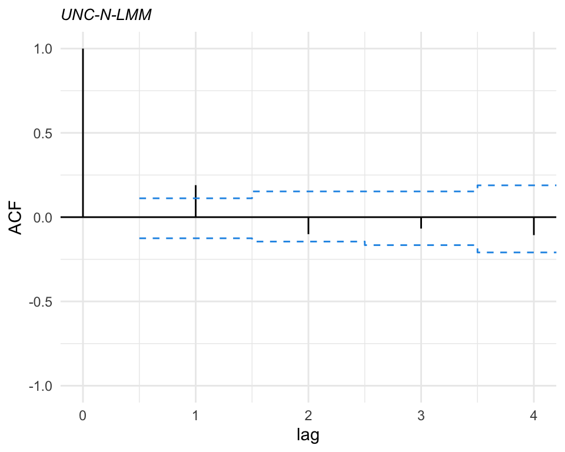

```r
acfresid(fskewlmm, maxLag = 4, calcCI = TRUE) %>% plot()
```

## Available S3 methods

The following methods/functions are available:

- plot
- print
- summary
- residuals
- ranef
- fitted
- predict
- update
- mahalDist
- mahalDistCens

## Remarks

- The misspecification of the distributional assumption may result in invalid statistical inferences, especially when dealing with heavy tails and skewness
- For instance, substantial bias in the ML estimates of regression parameters can result when the random-effects distribution is misspecified (Drikvandi et al., 2017)Drikvandi, R., Verbeke, G., & Molenberghs, G. (2017). Diagnosing misspecification of the random-effects distribution in mixed models. *Biometrics*, **73**(1), 63-71.
- In longitudinal studies, repeated measures are collected over time and hence the error term can be serially correlated (not necessarily handled by the random effects specification)

## Challenge #1: Within subject serial correlation

## Within subject serial correlation

The following dependence structures can be helpful to model serial correlation:

1. **Uncorrelated** (UNC): \(\boldsymbol{\Omega}_i = \sigma^2_e \mathbf{I}_{n_i}\).
2. **Autoregressive dependence of order** \(p\) (AR(\(p\))): \[\boldsymbol{\Omega}_i = \sigma^2_e \mathbf{R}_i = \frac{\sigma^2_e}{1 - \phi_1 \rho_1 - \ldots - \phi_p \rho_p} [\rho_{|r-s|}],\] where \(\rho_1, \ldots, \rho_p\) are the theoretical autocorrelations of the process and functions of \(\boldsymbol{\phi} = (\phi_1, \ldots, \phi_p)^\top\), and they satisfy the Yule-Walker equations.
3. **Damped exponential correlation** (DEC): \[\boldsymbol{\Omega}_i = \sigma_e^2 \mathbf{R}_i = \sigma_e^2 \left[ \phi_1^{|t_{ij} - t_{ik}|^{\phi_2}} \right], \quad 0 < \phi_1 < 1, \phi_2 > 0.\]

## Within subject serial correlation in R

We can fit an LMM with various correlation structures with the **nlme** package by specifying the `correlation` argument:

```r
# Autoregressive dependence of order 1
fnlmeAR1 = update(fnlme, correlation = corAR1(), method = "ML",
                  control = lmeControl(maxIter = 200, msMaxIter = 200,
                                       msMaxEval = 100, opt='optim'))
```

And with the **skewlmm** package using the `depStruct` argument:

```r
# Autoregressive dependence of order 1
fskewlmmAR1 = update(fskewlmm, depStruct = "ARp")
```

## `smn.lmm` vs `lme`

```r
# Using smn.lmm
summary(fskewlmmAR1)
```

```
## Linear mixed models with distribution norm and dependency structure ARp
## Call:
## smn.lmm(data = miceweight, formFixed = weight ~ treat * weekt,
##     groupVar = "mouseID", formRandom = ~weekt, depStruct = "ARp")
##
## Distribution norm
## Random effects:
##   Formula: ~weekt
##   Structure:
##   Estimated variance (D):
##             (Intercept)     weekt
## (Intercept)   11.813242 1.6041352
## weekt          1.604135 0.3610366
##
## Fixed effects: weight ~ treat * weekt
## with approximate confidence intervals
##                    Value Std.error CI 95% lower CI 95% upper
## (Intercept)   44.2116106 1.5168291   41.2386801   47.1845410
## treatT1        0.6134184 1.7744707   -2.8644802    4.0913171
## treatT2       -1.1315595 1.8717922   -4.8002047    2.5370858
## weekt          1.8422904 0.4649208    0.9310624    2.7535183
## treatT1:weekt -0.1434296 0.5368396   -1.1956158    0.9087566
## treatT2:weekt -0.5968562 0.5566771   -1.6879231    0.4942108
##
## Dependency structure: ARp
##   Estimate(s):
##     sigma2       phi1
## 10.5285097  0.6736481
##
## Model selection criteria:
##    logLik      AIC      BIC
##  -850.458 1722.916 1764.089
##
## Number of observations: 312
## Number of groups: 52
```

```r
# Using lme4
summary(fnlmeAR1)
```

```
## Linear mixed-effects model fit by maximum likelihood
##   Data: miceweight
##        AIC     BIC    logLik
##   1722.517 1763.69 -850.2584
##
## Random effects:
##  Formula: ~weekt | mouseID
##  Structure: General positive-definite, Log-Cholesky parametrization
##             StdDev    Corr
## (Intercept) 3.2523021 (Intr)
## weekt       0.5743535 0.926
## Residual    4.5337384
##
## Correlation Structure: AR(1)
##  Formula: ~1 | mouseID
##  Parameter estimate(s):
##       Phi
## 0.6933295
## Fixed effects:  weight ~ treat * weekt
##                  Value Std.Error  DF   t-value p-value
## (Intercept)   44.22118 1.4072319 257 31.424235  0.0000
## treatT1        0.59932 1.7371247  49  0.345007  0.7316
## treatT2       -1.14040 1.7519896  49 -0.650917  0.5181
## weekt          1.84433 0.3973757 257  4.641279  0.0000
## treatT1:weekt -0.14241 0.4905312 257 -0.290319  0.7718
## treatT2:weekt -0.59691 0.4947287 257 -1.206534  0.2287
##  Correlation:
##               (Intr) tretT1 tretT2 weekt  trtT1:
## treatT1       -0.810
## treatT2       -0.803  0.651
## weekt          0.287 -0.232 -0.230
## treatT1:weekt -0.232  0.287  0.187 -0.810
## treatT2:weekt -0.230  0.187  0.287 -0.803  0.651
##
## Standardized Within-Group Residuals:
##         Min          Q1         Med          Q3         Max
## -2.71637763 -0.56242622 -0.01053673  0.52145617  2.42664566
##
## Number of Observations: 312
## Number of Groups: 52
```

## Within subject serial correlation in R

We can perform likelihood ratio tests to compare the fitted objects as follows:

```r
lr.test(fskewlmmAR1, fskewlmm)
```

```
##
## Model selection criteria:
##               logLik      AIC      BIC
## fskewlmmAR1 -850.458 1722.916 1764.089
## fskewlmm    -862.978 1745.957 1783.387
##
##     Likelihood-ratio Test
##
## chi-square statistics =  25.04094
## df =  1
## p-value =  5.612572e-07
##
## The null hypothesis that both models represent the
## data equally well is rejected at level  0.05
```

## Checking for residual serial correlation

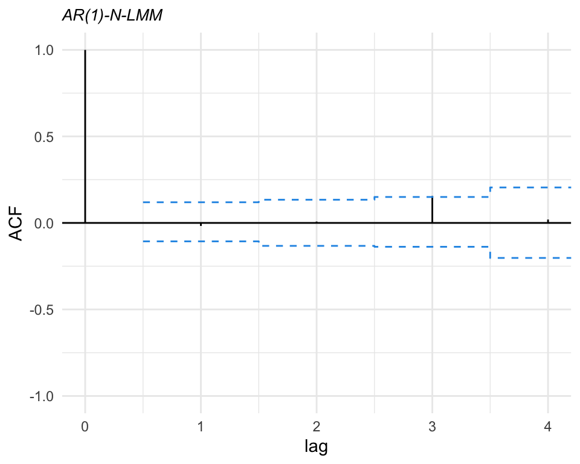

```r
acfresid(fskewlmmAR1, maxLag = 4, calcCI = TRUE) %>% plot()
```

## Challenge #2: Outliers

## Handling outliers in LMM

A possible approach to reduce the effects of outliers when analyzing longitudinal data is to replace usual normality assumptions by **heavier-than-normal tailed distributions**.

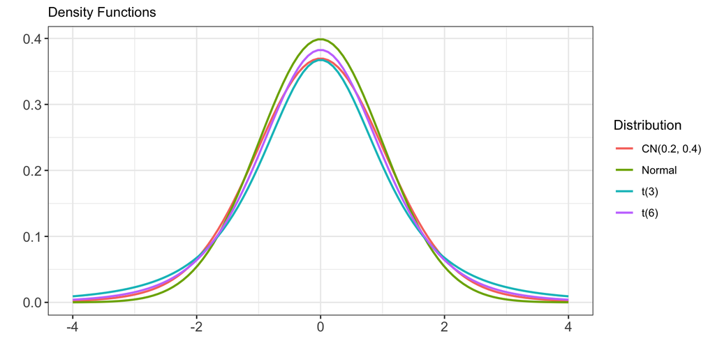

## Handling outliers in LMM

In a previous workSchumacher, F. L., Lachos, V. H., & Matos, L. A. (2021). Scale mixture of skew‐normal linear mixed models with within‐subject serial dependence. *Statistics in medicine*, 40(7)., we proposed the use the Scale Mixture of Normal (SMN) distributions:

\[ \left( \begin{array}{c} \textbf{b}_i \\ \boldsymbol{\epsilon}_i \end{array}\right) \stackrel {{\rm ind}}{\sim} \textrm{SMN}_{q+n_i} \left( \left(\begin{array}{c} \mathbf{0}\\ \mathbf{0} \end{array} \right), \left(\begin{array}{cc} \mathbf{D} & \mathbf{0} \\ \mathbf{0} & \boldsymbol{\Sigma}_i \end{array} \right); H \right), \]

where

- the tail behavior depends on the distribution function specified by \(H\), including the distributions normal, Student-t, Slash, and contaminated-normal,
- \(\boldsymbol{\Sigma}_i = \sigma_e^2 \mathbf{R}_i\), with \(\mathbf{R}_i = \mathbf{R}_i(\boldsymbol{\phi})\), \(\boldsymbol{\phi}=(\phi_1,\ldots,\phi_p)^\top\), is a structured matrix.

## Fitting a SMN-LMM to miceweight

Updating the previous fitted model to consider the \(t\) and CN distributions to miceweight data:

```r
ftAR1 <- update(fskewlmmAR1, distr = "t")
fcnAR1 <- update(fskewlmmAR1, distr = "cn")

criteria(list(normal = fskewlmmAR1, t = ftAR1, cn = fcnAR1)) %>% kable()
```

|  | logLik | npar | AIC | BIC |
| --- | --- | --- | --- | --- |
| normal | -850.4579 | 11 | 1722.916 | 1764.089 |
| t | -819.1339 | 12 | 1662.268 | 1707.184 |
| cn | -815.7971 | 13 | 1657.594 | 1706.253 |

## Fitting a CN-LMM to miceweight

```r
summary(fcnAR1)
```

```
## Linear mixed models with distribution cn and dependency structure ARp
## Call:
## smn.lmm(data = miceweight, formFixed = weight ~ treat * weekt,
##     groupVar = "mouseID", formRandom = ~weekt, depStruct = "ARp",
##     distr = "cn")
##
## Distribution cn with nu = 0.4349053 0.1426085
##
## Random effects:
##   Formula: ~weekt
##   Structure:
##   Estimated variance (D):
##             (Intercept)     weekt
## (Intercept)   5.2180664 0.7633666
## weekt         0.7633666 0.1430489
##
## Fixed effects: weight ~ treat * weekt
## with approximate confidence intervals
##                     Value Std.error CI 95% lower CI 95% upper
## (Intercept)   42.60777956 1.2565464   40.1449938   45.0705653
## treatT1        0.60421060 1.4760881   -2.2888688    3.4972900
## treatT2       -0.38441693 1.5243888   -3.3721641    2.6033302
## weekt          1.15530811 0.4107661    0.3502213    1.9603949
## treatT1:weekt  0.46052571 0.4764984   -0.4733940    1.3944455
## treatT2:weekt -0.04879976 0.4680949   -0.9662488    0.8686493
##
## Dependency structure: ARp
##   Estimate(s):
##    sigma2      phi1
## 2.8646272 0.7740477
##
## Model selection criteria:
##    logLik      AIC      BIC
##  -815.797 1657.594 1706.253
##
## Number of observations: 312
## Number of groups: 52
```

## Challenge #3: Skewness

## Handling skewness in LMM

In applications, skewness is often handled by log-transformations. However, interpreting model estimates with respect to log-transformed outcomes is challenging and usually non-intuitive.

Instead, we propose to consider skewed distributions in such situations, which can naturally accommodate such feature.

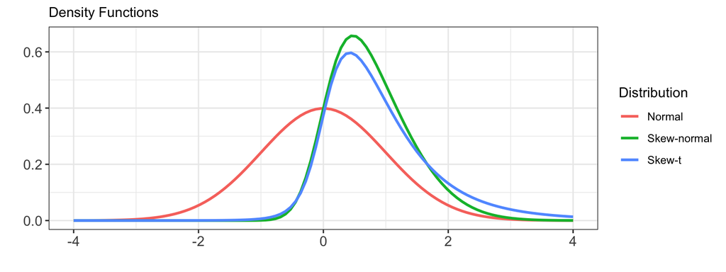

## Handling skewness in LMM

In this context, the flexible family of distributions Scale Mixture of Skew-Normal can be considered

\[ \left( \begin{array}{c} \textbf{b}_i \\ \boldsymbol{\epsilon}_i \end{array}\right) \stackrel {{\rm ind}}{\sim} \textrm{SMSN}_{q+n_i} \left( \left(\begin{array}{c} c\boldsymbol{\Delta} \\ \mathbf{0} \end{array} \right), \left(\begin{array}{cc} \mathbf{D} & \mathbf{0} \\ \mathbf{0} & \boldsymbol{\Sigma}_i \end{array} \right), \left(\begin{array}{c} \boldsymbol{\lambda} \\ \mathbf{0} \end{array} \right); H \right), \]

- the chosen location parameter for \(\mathbf{b}_i\) ensures that \(E\{\mathbf{b}_i\} = E\{\boldsymbol{\epsilon}_i\} = \mathbf{0}\), so \(E\{\mathbf{Y}_i\} =\textbf{X}_i\boldsymbol{\beta}\),
- \(\boldsymbol{\lambda}\) regulates the skewness,
- when \(\boldsymbol{\lambda}=\mathbf{0}\), the SMN is obtained as a special case.

## Fitting a SCN-LMM to miceweight

We can fit a skewed model to the miceweight data with AR(1) correlation using the following syntax:

```r
fscnAR1 <- smsn.lmm(formFixed = weight ~ treat*weekt, formRandom = ~ weekt,
                   groupVar = "mouseID", data = miceweight, depStruct = "ARp",
                   distr = "scn")

criteria(list(normal = fskewlmmAR1, cn = fcnAR1, scn = fscnAR1)) %>% kable()
```

|  | logLik | npar | AIC | BIC |
| --- | --- | --- | --- | --- |
| normal | -850.4579 | 11 | 1722.916 | 1764.089 |
| cn | -815.7971 | 13 | 1657.594 | 1706.253 |
| scn | -809.4435 | 15 | 1648.887 | 1705.032 |

## Fitting a SCN-LMM to miceweight

```r
lr.test(fscnAR1, fcnAR1)
```

```
##
## Model selection criteria:
##           logLik      AIC      BIC
## fscnAR1 -809.443 1648.887 1705.032
## fcnAR1  -815.797 1657.594 1706.253
##
##     Likelihood-ratio Test
##
## chi-square statistics =  12.70716
## df =  2
## p-value =  0.001740502
##
## The null hypothesis that both models represent the
## data equally well is rejected at level  0.05
```

## Fitting a SCN-LMM to miceweight

```r
summary(fscnAR1)
```

```
## Linear mixed models with distribution scn and dependency structure ARp
## Call:
## smsn.lmm(data = miceweight, formFixed = weight ~ treat * weekt,
##     groupVar = "mouseID", formRandom = ~weekt, depStruct = "ARp",
##     distr = "scn")
##
## Distribution scn with nu = 0.4749987 0.1378151
##
## Random effects:
##   Formula: ~weekt
##   Structure:
##   Estimated variance (D):
##             (Intercept)     weekt
## (Intercept)    12.49990 1.5979104
## weekt           1.59791 0.2805946
##
## Fixed effects: weight ~ treat * weekt
## with approximate confidence intervals
##                     Value Std.error CI 95% lower CI 95% upper
## (Intercept)   44.21203515 1.6914356   40.8968824   47.5271879
## treatT1       -0.26795376 1.3757840   -2.9644409    2.4285333
## treatT2       -0.48368047 1.3266640   -3.0838941    2.1165332
## weekt          1.38022226 0.4030417    0.5902751    2.1701694
## treatT1:weekt  0.36485313 0.4302992   -0.4785177    1.2082240
## treatT2:weekt -0.09452354 0.4091909   -0.8965230    0.7074759
##
## Dependency structure: ARp
##   Estimate(s):
##    sigma2      phi1
## 2.4720220 0.6774895
##
## Skewness parameter estimate: 14.55327 4.307805
##
## Model selection criteria:
##    logLik      AIC      BIC
##  -809.443 1648.887 1705.032
##
## Number of observations: 312
## Number of groups: 52
```

## Evaluating the goodness of fit

We can assess the goodness of fit using a Healy-type plot:

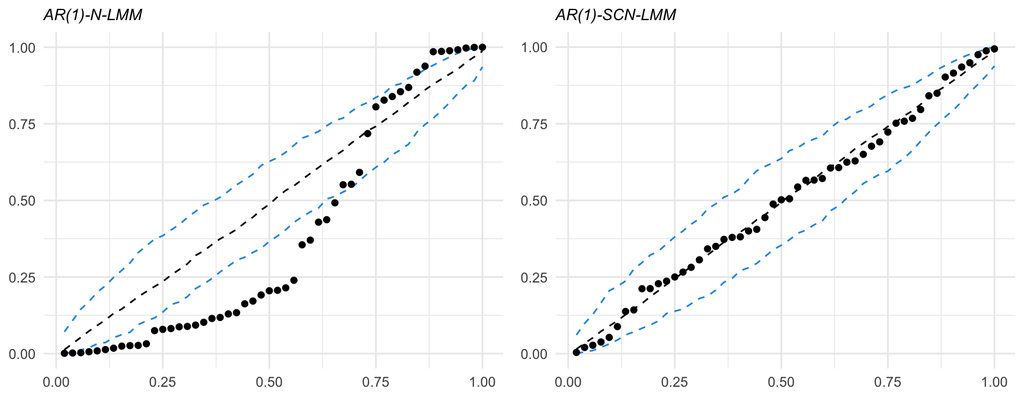

```r
grid.arrange(healy.plot(fskewlmmAR1, calcCI = TRUE) + geom_point(size = 1.5),
             healy.plot(fscnAR1, calcCI = TRUE) + geom_point(size = 1.5), nrow = 1)
```

## Evaluating the goodness of fit

We can check for residual correlation based on ACF:

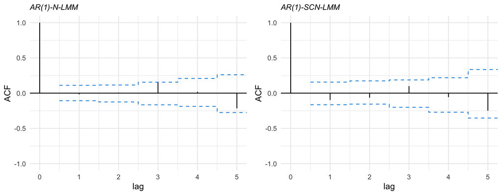

```r
grid.arrange(plot(acfresid(fskewlmmAR1, calcCI = TRUE, maxLag = 5)),
             plot(acfresid(fscnAR1, calcCI = TRUE, maxLag = 5)), nrow = 1)
```

## Evaluating the goodness of fit

We can evaluate atypical observations using the Mahalanobis distance:

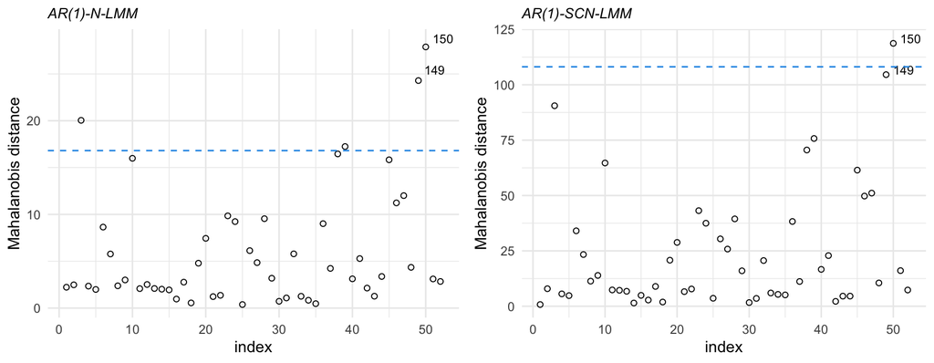

```r
grid.arrange(plot(mahalDist(fskewlmmAR1), nlabels = 2),
             plot(mahalDist(fscnAR1), nlabels = 2), nrow = 1)
```

```r
confint(fscnAR1) %>% round(3)
```

```
##               Estimate CI 95% lower CI 95% upper
## (Intercept)     44.212       40.897       47.527
## treatT1         -0.268       -2.964        2.429
## treatT2         -0.484       -3.084        2.117
## weekt            1.380        0.590        2.170
## treatT1:weekt    0.365       -0.479        1.208
## treatT2:weekt   -0.095       -0.897        0.707
## sigma2           2.472        1.519        3.425
## phiAR1           0.677        0.249        1.106
## Dsqrt11          3.511        1.128        5.894
## Dsqrt12          0.416       -0.095        0.928
## Dsqrt22          0.328       -0.570        1.226
## lambda1         14.553           NA           NA
## lambda2          4.308           NA           NA
## nu1              0.475           NA           NA
## nu2              0.138           NA           NA
```

```r
boot_fscnAR1 <- confint(fscnAR1, method = "bootstrap", B=100)
boot_fscnAR1 %>% round(digits = 3)
```

```
##               Estimate   2.5%  97.5%
## (Intercept)     44.212 41.817 46.281
## treatT1         -0.268 -2.807  1.881
## treatT2         -0.484 -3.172  1.690
## weekt            1.380  0.958  2.000
## treatT1:weekt    0.365 -0.272  0.950
## treatT2:weekt   -0.095 -0.833  0.471
## sigma2           2.472  1.485  3.086
## phiAR1           0.677  0.351  0.768
## Dsqrt11          3.511  2.771  4.098
## Dsqrt12          0.416  0.154  0.624
## Dsqrt22          0.328  0.115  0.640
## lambda1         14.553 12.956 90.634
## lambda2          4.308  2.067 34.217
## nu1              0.475  0.301  0.624
## nu2              0.138  0.103  0.188
```

## Under implementation: influence diagnostic

In a recent workCastro, K.T., Matos, L.A., Schumacher, F.L. (2024+) Diagnostic analysis in scale mixture of skew-normal linear mixed models. *Under review*., we explored diagnostic analysis in SMSN-LMM by deriving:

- Case-deletion measures;
- Local influence (under several perturbations).

Such tools will be incorporated in the **skewlmm** package soon.

## Challenge #4: Censored/Missing data

## Censored/Missing data in longitudinal studies

Censoring can occur when measurement techniques are subject to limits of detection, above or below which the exact measure is not detectable .

Missing data can occur in longitudinal studies for different reasons. E.g.:

- Loss to follow up;
- Dropout (deliberate discontinuation);
- Intermittent missing (missed appointments).

A missing observation can be considered as a censored observation for which the censoring interval is the full real line (\(-\infty,\infty\)).

**Remark:**  
The context of censoring presented here is different from the one used in time-to-event outcomes.

## Simulating missingness in miceweight

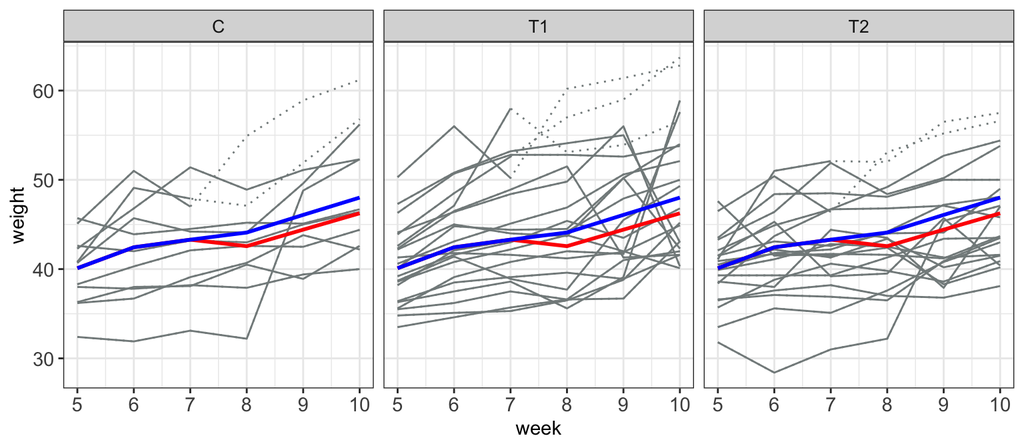

## Handling missingness in longitudinal data

- Under a missing at random mechanism, a maximum likelihood-based estimates (e.g., LMM or GLMM) will usually yield unbiased estimates (as opposed to marginal models, such as GEE).
- For improve the performance, a model-based approach based on Expectation-Maximization (EM) algorithm can be used for likelihood-based estimation, where missing values are treated as latent variable
- Full model specification can be found in Matos et al.Matos, L. A., Prates, M. O., Chen, M. H., & Lachos, V. H. (2013). Likelihood-based inference for mixed-effects models with censored response using the multivariate-t distribution. Statistica Sinica, 1323-1345.
- This method is implemented in the context of censored data as part of the R package **skewlmm**.

## Key arguments of `smn.clmm` function

```r
smn.clmm(data, formFixed, groupVar, formRandom = ~1, depStruct = "UNC",
         ci, lcl, ucl, timeVar = NULL, distr = "norm",
         nufix = FALSE, pAR = 1, control = lmmControl())
```

- `depStruct` a character indicating the dependence structure
- `timeVar` a character containing the name of the time variable
- `pAR` a number indicating the order of the autoregressive process
- `distr` a character indicating which distribution should be used
- `ci` a character containing the name of the censoring indicator variable
- `lcl` a character containing the name of the lower censoring limit in data
- `ucl` a character containing the name of the upper censoring limit in data

## Handling missingness in longitudinal data

```r
fitCens <- smn.clmm(formFixed = weight ~ treat*weekt, formRandom = ~ weekt,
                   groupVar = "mouseID", data = miceweight_miss, depStruct = "ARp",
                   ci = "miss", lcl = "lcl")

fitCensT <- update(fitCens, distr = "t")
```

```r
criteria(list(normal = fitCens, t = fitCensT)) %>% kable()
```

|  | logLik | npar | AIC | BIC |
| --- | --- | --- | --- | --- |
| normal | -1694.873 | 11 | 3411.746 | 3460.544 |
| t | -1674.423 | 12 | 3372.846 | 3426.080 |

## Handling missingness in longitudinal data

```r
summary(fitCensT)$tableFixed %>% kable(digits=4)
```

|  | Value | Std.error | CI 95% lower | CI 95% upper |
| --- | --- | --- | --- | --- |
| (Intercept) | 42.4492 | 0.9968 | 40.4955 | 44.4030 |
| treatT1 | 1.7185 | 1.2021 | -0.6375 | 4.0746 |
| treatT2 | -0.0171 | 1.2628 | -2.4922 | 2.4580 |
| weekt | 1.1858 | 0.3449 | 0.5097 | 1.8619 |
| treatT1:weekt | 0.6570 | 0.4029 | -0.1327 | 1.4467 |
| treatT2:weekt | -0.1879 | 0.4135 | -0.9983 | 0.6226 |

## Current/future in SMSN-LMM

**SMSN-LMM:**

[figure not shown]

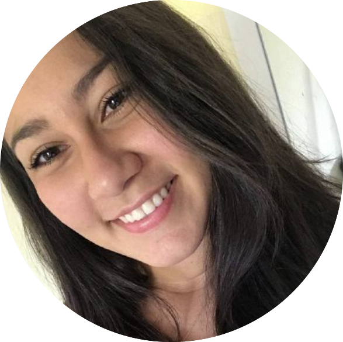

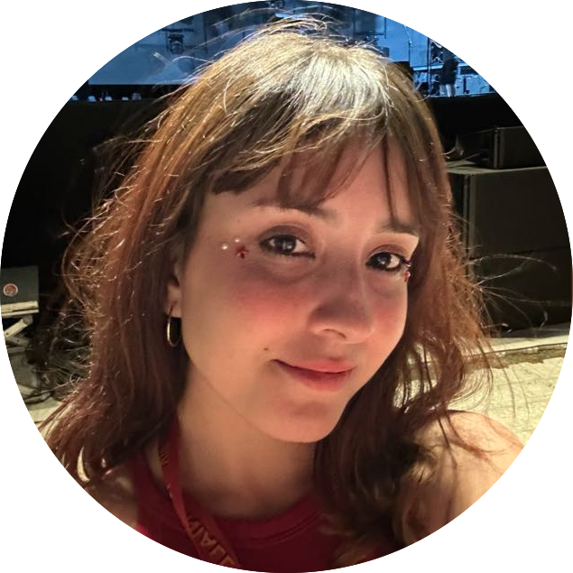

- Sandwich-type estimation for the standard errors
- Diagnostic analysis
- Crossed random effects
- Starting values

**Censored response:**

- SMSN
- Diagnostic analysis
- Starting values

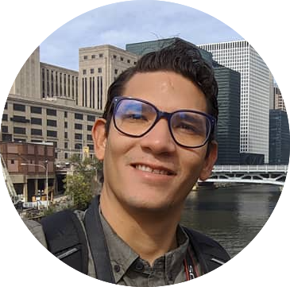

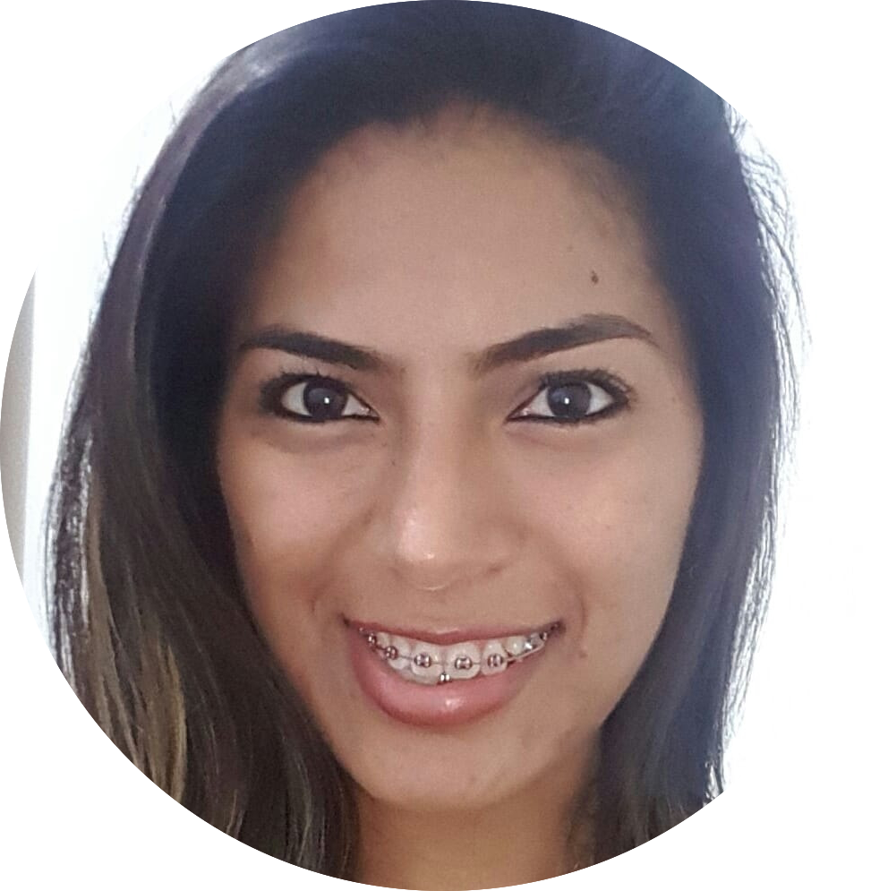

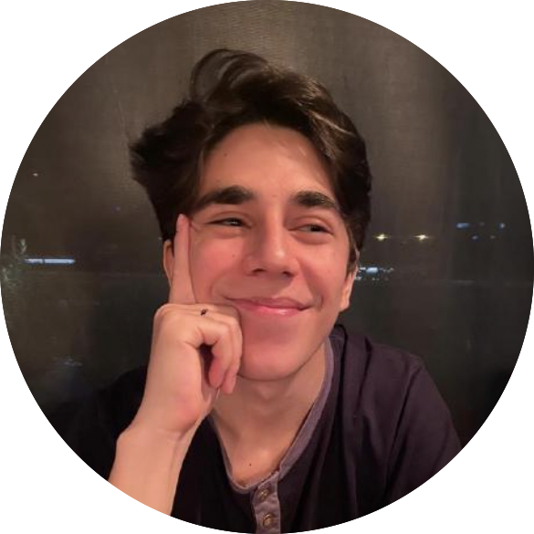

## Thank you! Obrigada!

[figure not shown]

Larissa Avila Matos  
Associate Professor - Statistics

larissam@unicamp.br

**Suporte:**

[figure not shown]

[figure not shown]

[figure not shown]

[figure not shown]